# Thinking Like a Bayesian (Part 1)

## Introduction

- On Monday:
  - Refresher on probability theory
  - What does each distribution do?
    - beta $\to$ outcomes limited to [0, 1]
    - binomial $\to$ binary outcomes
    - gamma $\to$ continuous & positive outcomes; skewed right
    - normal $\to$ continuous outcomes; mound-shaped & symmetric distribution
    - Poisson $\to$ count outcomes; skewed right
    - uniform $\to$ each outcome has equal probability; rectangular distribution
- Today: building up Bayesian analysis concepts

## R Set Up

- To follow today’s lecture, please load the following packages:

```r
library(tidyverse)
library(janitor)
library(bayesrules)
```

- If you need to install any, you can do so with the `install.packages()` function.

```r
install.packages("bayesrules")
```

## Thinking Like a Bayesian

- Bayesian analysis involves updating beliefs based on observed data.

[interactive chart not shown]

## Thinking Like a Bayesian

- Bayesian analysis involves updating beliefs based on observed data.

[interactive chart not shown]

## Thinking Like a Bayesian

- Bayesian analysis involves updating beliefs based on observed data.

[interactive chart not shown]

## Thinking Like a Bayesian

- Bayesian analysis involves updating beliefs based on observed data.

[interactive chart not shown]

## Thinking Like a Bayesian

- This is the natural Bayesian knowledge-building process of:
  - acknowledging your preconceptions (prior distribution),

[interactive chart not shown]

## Thinking Like a Bayesian

- This is the natural Bayesian knowledge-building process of:
  - acknowledging your preconceptions (prior distribution),
  - using data (data distribution) to update your knowledge (posterior distribution),

[interactive chart not shown]

## Thinking Like a Bayesian

- This is the natural Bayesian knowledge-building process of:
  - acknowledging your preconceptions (prior distribution),
  - using data (data distribution) to update your knowledge (posterior distribution), and
  - repeating (posterior distribution $\to$ new prior distribution)

[interactive chart not shown]

## Thinking Like a Bayesian

- Bayesian and frequentist analyses share a common goal: to learn from data about the world around us.
  - Both Bayesian and frequentist analyses use data to fit models, make predictions, and evaluate hypotheses.
  - When working with the same data, they will typically produce a similar set of conclusions.
- Statisticians typically identify as either a “Bayesian” or “frequentist” …
  - We are not going to “take sides.”
  - We will see these as tools in our toolbox.

## Thinking Like a Bayesian

- **Bayesian probability:** the relative plausibility of an event. This considers prior belief.

[interactive chart not shown]

## Thinking Like a Bayesian

- **Frequentist probability:** the long-run relative frequency of a repeatable event. This does not consider prior belief.

[interactive chart not shown]

## Thinking Like a Bayesian

- The Bayesian framework depends upon prior information, data, and the balance between them.
  - The balance between the prior information and data is determined by the relative strength of each.

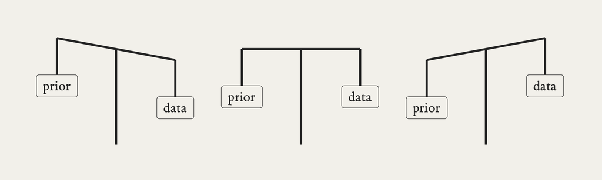

- When we have little data, our posterior can rely more on prior knowledge.
- As we collect more data, the prior can lose its influence.

## Thinking Like a Bayesian

- We can also use this approach to combine analysis results.

[interactive chart not shown]

## Thinking Like a Bayesian

- We will use an example to work through Bayesian logic.
- The Collins Dictionary named “fake news” the 2017 term of the year.
  - Fake, misleading, and biased news has proliferated along with online news and social media platforms which allow users to post articles with little quality control.
- We want to flag articles as “real” or “fake.”
- We’ll examine a sample of 150 articles which were posted on Facebook and fact checked by five BuzzFeed journalists (Shu et al. 2017).

## Thinking Like a Bayesian

- Information about each article is stored in the `fake_news` dataset in the `bayesrules` package.

```r
fake_news <- bayesrules::fake_news
print(colnames(fake_news))
```

```
 [1] "title"                   "text"
 [3] "url"                     "authors"
 [5] "type"                    "title_words"
 [7] "text_words"              "title_char"
 [9] "text_char"               "title_caps"
[11] "text_caps"               "title_caps_percent"
[13] "text_caps_percent"       "title_excl"
[15] "text_excl"               "title_excl_percent"
[17] "text_excl_percent"       "title_has_excl"
[19] "anger"                   "anticipation"
[21] "disgust"                 "fear"
[23] "joy"                     "sadness"
[25] "surprise"                "trust"
[27] "negative"                "positive"
[29] "text_syllables"          "text_syllables_per_word"
```

## Thinking Like a Bayesian

- Suppose that the most recent article posted to a social media platform is titled: *The president has a funny secret!*
  - Some features of this title probably set off some red flags.
  - For example, the usage of an exclamation point might seem like an odd choice for a real news article.
- In the dataset, what is the split of real and fake articles?

```r
fake_news %>% tabyl(type)
```

## Thinking Like a Bayesian

- In the dataset, what is the split of real and fake articles?

```r
fake_news %>% tabyl(type)
```

| type | n | percent |
| --- | --- | --- |
| fake | 60 | 0.4 |
| real | 90 | 0.6 |

## Thinking Like a Bayesian

- What does the data say?

```r
fake_news %>% tabyl(title_has_excl, type) %>%
  adorn_percentages("col") %>%
  adorn_pct_formatting(digits = 2) %>%
  adorn_ns()
```

## Thinking Like a Bayesian

- What does the data say?

```r
fake_news %>% tabyl(title_has_excl, type) %>%
  adorn_percentages("col") %>%
  adorn_pct_formatting(digits = 2) %>%
  adorn_ns()
```

| title_has_excl | fake | real |
| --- | --- | --- |
| FALSE | 73.33% (44) | 97.78% (88) |
| TRUE | 26.67% (16) | 2.22% (2) |

- 26.67% of fake news titles use ! vs 2.22% of real news titles use !

## Thinking Like a Bayesian

- We now have two pieces of contradictory information.
  - Our prior information suggested that incoming articles are most likely real.
  - However, the exclamation point data is more consistent with fake news.

[interactive chart not shown]

## Building a Bayesian Model

- Thinking like Bayesians, we know that balancing both pieces of information is important in developing a posterior understanding of whether the article is fake.
- Our fake news analysis studies two variables:
  - an article’s fake vs real status and
  - its use of exclamation points.
- We can represent the randomness in these variables using probability models.

## Building a Bayesian Model

- Let’s now formalize our prior understanding of whether the new article is fake.
- Based on our data, we saw that 40% of articles are fake and 60% are real.
  - Before reading the new article, there’s a 0.4 *prior* probability that it’s fake.

$$P\left[B\right] = 0.40 \text{ and } P\left[B^c\right] = 0.60$$

- Remember that a valid probability model must:
  1. account for all possible events
  2. assign prior probabilities to each event
  3. have probabilities that sum to 1

## Building a Bayesian Model

- Revisiting the contingency table for conditional probabilities,

| title_has_excl | fake | real |
| --- | --- | --- |
| FALSE | 73.3% (44) | 97.8% (88) |
| TRUE | 26.7% (16) | 2.2% (2) |

- If an article is fake ($B$), what is the probability that it uses exclamation points in the title?
- If an article is real ($B^c$), what is the probability that it uses exclamation points in the title?

## Building a Bayesian Model

- We have the following conditional probabilities:
  - If an article is fake, then there is about a 27% chance it uses exclamation points in the title.
    - $P[A|B]=0.2667$
  - If an article is real, then there is only a 2% chance it uses exclamation points in the title.
    - $P[A|B^c]=0.0222$
- Exclamation point usage is much more likely among fake news than real news.
  - We have evidence that the article is fake.

## Building a Bayesian Model

- Note that we know that the incoming article used exclamation points ($A$), but we do not actually know if the article is fake ($B$ or $B^c$).
- In this case, we compared $P[A|B]$ and $P[A|B^c]$ to ascertain the **relative likelihood** of observing $A$ under different scenarios. That is,
  - $L\left[B|A\right] = P\left[A|B\right]$ $\to$ the likelihood of fake given !
  - $L\left[B^c|A\right] = P\left[A|B^c\right]$ $\to$ the likelihood of real given !

## Building a Bayesian Model

| Event | *B* | *B<sup>c</sup>* | Total |
| --- | --- | --- | --- |
| Prior Probability | 0.4 | 0.6 | 1.0 |
| Likelihood | 0.2667 | 0.0222 | 0.2889 |

$$L\left[B|A\right] = P\left[A|B\right] \text{ and } L\left[B^c|A\right] = P\left[A|B^c\right]$$

- It is important for us to note that the likelihood function is *not* a probability function.
  - This is a framework to determine the relative compatibility of our exclamation point data with $B$ and $B^c$.

## Building a Bayesian Model

| Event | *B* (fake) | *B<sup>c</sup>* (real) | Total |
| --- | --- | --- | --- |
| Prior Probability | 0.4 | 0.6 | 1.0 |
| Likelihood | 0.2667 | 0.0222 | 0.2889 |

- The prior evidence suggested the article is most likely real,

$$P[B] = 0.4 < P[B^c] = 0.6$$

- The data, however, is more consistent with the article being fake,

$$L[B|A] = 0.2667 > L[B^c|A] = 0.0222$$

## Building a Bayesian Model

- We can summarize our probabilities in a table,

|  | $B$ | $B^c$ | Total |
| --- | --- | --- | --- |
| $A$ |  |  |  |
| $A^c$ |  |  |  |
| **Total** | 0.4 | 0.6 | 1 |

- As found earlier, $P[A|B] = 0.2667$ and $P[A|B^c]=0.0222$.
- Find $P[A \cap B]$.

## Building a Bayesian Model

- We can summarize our probabilities in a table,

|  | $B$ | $B^c$ | Total |
| --- | --- | --- | --- |
| $A$ |  |  |  |
| $A^c$ |  |  |  |
| **Total** | 0.4 | 0.6 | 1 |

- As found earlier, $P[A|B] = 0.2667$ and $P[A|B^c]=0.0222$.

$$\begin{align*}
P[A \cap B] &= P[A|B] \times P[B] \\
&= 0.2667 \times 0.4 \\
&= 0.1067
\end{align*}$$

## Building a Bayesian Model

- Here’s what we know,

|  | $B$ | $B^c$ | Total |
| --- | --- | --- | --- |
| $A$ | 0.1067 |  |  |
| $A^c$ |  |  |  |
| **Total** | 0.4 | 0.6 | 1 |

- As found earlier, $P[A|B] = 0.2667$ and $P[A|B^c]=0.0222$.
- Find $P[A^c \cap B]$.

## Building a Bayesian Model

- Here’s what we know,

|  | $B$ | $B^c$ | Total |
| --- | --- | --- | --- |
| $A$ | 0.1067 |  |  |
| $A^c$ |  |  |  |
| **Total** | 0.4 | 0.6 | 1 |

- As found earlier, $P[A|B] = 0.2667$ and $P[A|B^c]=0.0222$.

$$\begin{align*}
P[A^c \cap B] &= P[A^c|B] \times P[B] \\
&= \left(1-P[A|B]\right) \times P[B] \\
&= (1-0.2667) \times 0.4 \\
&= 0.2933
\end{align*}$$

## Building a Bayesian Model

- Here’s what we know,

|  | $B$ | $B^c$ | Total |
| --- | --- | --- | --- |
| $A$ | 0.1067 |  |  |
| $A^c$ | 0.2933 |  |  |
| **Total** | 0.4 | 0.6 | 1 |

- As found earlier, $P[A|B] = 0.2667$ and $P[A|B^c]=0.0222$.
- Find $P[A \cap B^c]$.

## Building a Bayesian Model

- Here’s what we know,

|  | $B$ | $B^c$ | Total |
| --- | --- | --- | --- |
| $A$ | 0.1067 |  |  |
| $A^c$ | 0.2933 |  |  |
| **Total** | 0.4 | 0.6 | 1 |

- As found earlier, $P[A|B] = 0.2667$ and $P[A|B^c]=0.0222$.

$$\begin{align*}
P[A \cap B^c] &= P[A|B^c] \times P[B^c] \\
&= 0.0222 \times 0.6 \\
&= 0.0133
\end{align*}$$

## Building a Bayesian Model

- Here’s what we know,

|  | $B$ | $B^c$ | Total |
| --- | --- | --- | --- |
| $A$ | 0.1067 | 0.0133 |  |
| $A^c$ | 0.2933 |  |  |
| **Total** | 0.4 | 0.6 | 1 |

- As found earlier, $P[A|B] = 0.2667$ and $P[A|B^c]=0.0222$.
- Find $P[A^c \cap B^c]$.

## Building a Bayesian Model

- Here’s what we know,

|  | $B$ | $B^c$ | Total |
| --- | --- | --- | --- |
| $A$ | 0.1067 | 0.0133 |  |
| $A^c$ | 0.2933 |  |  |
| **Total** | 0.4 | 0.6 | 1 |

- As found earlier, $P[A|B] = 0.2667$ and $P[A|B^c]=0.0222$.

$$\begin{align*}
P[A^c \cap B^c] &= P[A^c|B^c] \times P[B^c] \\
&= 0.9778 \times 0.6 \\
&= 0.5867
\end{align*}$$

## Building a Bayesian Model

- Here’s what we know,

|  | $B$ | $B^c$ | Total |
| --- | --- | --- | --- |
| $A$ | 0.1067 | 0.0133 |  |
| $A^c$ | 0.2933 | 0.5867 |  |
| **Total** | 0.4 | 0.6 | 1 |

- Finally,

$$\begin{align*}
&P[A] = 0.1067 + 0.0133 = 0.12 \\
&P[A^c] = 0.2933 + 0.5867 = 0.88
\end{align*}$$

## Building a Bayesian Model

- Using rules of probability, we have completed the table.

|  | $B$ | $B^c$ | Total |
| --- | --- | --- | --- |
| $A$ | 0.1067 | 0.0133 | 0.12 |
| $A^c$ | 0.2933 | 0.5867 | 0.88 |
| **Total** | 0.4 | 0.6 | 1 |

## Building a Bayesian Model

- With more information, we can finally find the probability that the latest article is fake.
- We will use the posterior probability, $P[B|A]$, which is found using Bayes’ Rule.
- **Bayes’ Rule**: For events $A$ and $B$,

$$P[B|A] = \frac{P[A \cap B]}{P[A]} = \frac{P[B] \times L[B|A]}{P[A]}$$

- But really, we can think about it like this,

$$\text{posterior} = \frac{\text{prior} \times \text{likelihood}}{\text{normalizing constant}}$$

## Building a Bayesian Model

- Let’s now apply Bayes’ Rule to our fake news example.

|  | $B$ | $B^c$ | Total |
| --- | --- | --- | --- |
| $A$ | 0.1067 | 0.0133 | 0.12 |
| $A^c$ | 0.2933 | 0.5867 | 0.88 |
| **Total** | 0.4 | 0.6 | 1 |

- Find $P[B|A]$.

## Building a Bayesian Model

- Applying Bayes’ Rule to our fake news example,

$$P[B|A] = \frac{P[A \cap B]}{P[A]} = \frac{0.1067}{0.12} = 0.889$$

- There is an 88.9% posterior probability that the article is fake given that it uses an exclamation point in the title.

## Building a Bayesian Model

- Comparing our prior and posterior probabilities,
  - **Prior:** $P[B] = 0.40$, i.e., before seeing the title, 40% chance the article is fake.
  - **Posterior:** $P[B|A] = 0.889$, i.e., after seeing the exclamation point in the title, 88.9% chance the article is fake.
- The exclamation point adds strong evidence to the article being fake.
  - Our posterior is much higher than our prior.

## Wrap Up

- Today we have introduced thinking like a Bayesian.
- The biggest take away: we now consider prior data/beliefs, rather than just the collected data.
- Next week: formalizing the Bayesian model with conjugate families.
  - Beta-Binomial
  - Gamma-Poisson
  - Normal-Normal